# PROJECT 1: Conspiracy theories

**Your task**

Given a bunch of comment threads from the r/conspiracies subreddit, develop a set of labels for categorizing them. Labels should be a single word or short phrase. Some threads might fit more than one label.

- Use methods from labs so far (keyword analysis, terminology extraction, topic models)
- No specific ‘correct’ answer; the process you use to develop the list is more important than the solution.

**Deliverables**

- List of labels
- For each label, the number of threads from the dataset that fit that label
- Discuss how the mix of labels has changed over time
- Annotated notebook(s) showing your process plus a brief write-up describing your conclusions

**To turn in**: download your notebooks as HTMLs file (File>Save and Export Notebook as...>HTML) and submit via canvas

```python
import re
from collections import Counter, defaultdict

import nltk
import numpy as np
import pandas as pd
from cytoolz import concat
from tqdm import tqdm
```

```python
df = pd.read_pickle("/data/conspiracy.pkl")
df
```

|  | date | text |
| --- | --- | --- |
| 0 | 2019-08-09 21:58:14 | Your post has been removed because it does not... |
| 1 | 2022-01-15 19:16:00 | Ugh. I am sick of seeing his face. He is so co... |
| 2 | 2022-10-24 16:25:16 | I’m not saying charges weren’t used, what I am... |
| 3 | 2016-10-28 15:10:41 | It's actually a callback to Tom Cruise's momen... |
| 4 | 2020-12-12 19:53:11 | All caps titles are not permitted as per rule ... |
| ... | ... | ... |
| 19993 | 2022-03-03 07:03:00 | Cry me a river. I'm speaking from my personal ... |
| 19994 | 2021-02-13 08:04:35 | What’s the conspiracy? All I see are political... |
| 19995 | 2016-12-06 19:21:36 | Remind people that this shit is larger and mor... |
| 19996 | 2015-12-06 16:25:01 | > you do not have time to go tell nasa yoursel... |
| 19997 | 2021-12-14 06:26:40 | good to know, i havent been able to get a stra... |

19969 rows × 2 columns

## Tokenize text

Tokenize in two steps: first find multiword expressions and then use them to divide text into 'words'

```python
import spacy
from spacy.matcher import Matcher

nlp = spacy.load(
    "en_core_web_sm", exclude=["parser", "ner", "lemmatizer", "attribute_ruler"]
)
```

```python
matcher = Matcher(nlp.vocab)
matcher.add(
    "Term",
    [
        [
            {"TAG": {"IN": ["JJ", "NN", "NNS", "NNP"]}},
            {"TAG": {"IN": ["JJ", "NN", "NNS", "NNP", "HYPH"]}, "OP": "*"},
            {"TAG": {"IN": ["NN", "NNS", "NNP"]}},
        ]
    ],
)


def get_phrases(doc):
    spans = matcher(doc, as_spans=True)
    return [tuple(tok.norm_ for tok in span) for span in spans]
```

### Find candidate terms

```python
docs = nlp.pipe(tqdm(df["text"]), n_process=2, batch_size=5)
candidates = Counter(concat(get_phrases(d) for d in docs))
```

```python
candidates.most_common(10)
```

### Use C-value algorithm to find terms

```python
freqs = defaultdict(Counter)
for c in candidates:
    freqs[len(c)][c] += candidates[c]
```

```python
def get_subterms(term):
    k = len(term)
    for m in range(k - 1, 1, -1):
        yield from nltk.ngrams(term, m)


def c_value(F, theta):

    termhood = Counter()
    longer = defaultdict(list)

    for k in sorted(F, reverse=True):
        for term in F[k]:
            if term in longer:
                discount = sum(longer[term]) / len(longer[term])
            else:
                discount = 0
            c = np.log2(k) * (F[k][term] - discount)
            if c > theta:
                termhood[term] = c
                for subterm in get_subterms(term):
                    if subterm in F[len(subterm)]:
                        longer[subterm].append(F[k][term])
    return termhood
```

```python
terms = c_value(freqs, theta=50)
```

```python
terms.most_common()[-5:]
```

### Save terms

```python
with open("terms.txt", "w") as f:
    for term in terms:
        print(" ".join(term), file=f)
```

## Second part of tokenization: tokenize texts using terms we just found

```python
from tokenizer import MWETokenizer

tokenizer = MWETokenizer(t.strip() for t in open("terms.txt"))
```

```python
df["tokens"] = [tokenizer.tokenize(txt) for txt in tqdm(df["text"])]
```

## Topic model

Next up: Using our tokenized texts, build a topic model

```python
import tomotopy as tp
```

```python
k = 50
min_df = 50
rm_top = 75
tw = tp.TermWeight.ONE
alpha = 0.1
eta = 0.01
tol = 1e-4
```

```python
%%time

mdl = tp.LDAModel(k=k, min_df=min_df, rm_top=rm_top, tw=tw, alpha=alpha, eta=eta)

for toks in df["tokens"]:
    mdl.add_doc(toks)

mdl.train(0)
last = mdl.ll_per_word
print(f"{0:5d} LL = {last:8.4f}", flush=True)

for i in range(50, 5000, 50):
    mdl.train(50, workers=4)
    ll = mdl.ll_per_word
    print(f"{i:5d} LL = {ll:8.4f}", flush=True)
    if ll - last < tol:
        break
    else:
        last = ll
```

[output not shown]

```python
", ".join(mdl.removed_top_words)
```

```python
import matplotlib.pyplot as plt
from scipy.spatial import distance
from sklearn.manifold import MDS, TSNE


def plot_topics(mdl, method="tsne", figsize=7):

    fig = plt.figure(figsize=(figsize, figsize))

    # x, y coords
    term_topics_dist = np.stack([mdl.get_topic_word_dist(k) for k in range(mdl.k)])
    if method == "mds":
        dist = distance.squareform(distance.pdist(term_topics_dist, "jensenshannon"))
        coords = MDS(2, dissimilarity="precomputed").fit_transform(dist)
    elif method == "tsne":
        if mdl.k <= 20:
            p = mdl.k - 1
        else:
            p = 20
        coords = TSNE(
            2,
            metric=distance.jensenshannon,
            perplexity=p,
            init="pca",
            learning_rate="auto",
            n_jobs=-1,
        ).fit_transform(term_topics_dist)
    else:
        raise ValueError(f"Method {method} unknown")

    # size of the circle
    doc_topic_dists = np.stack([doc.get_topic_dist() for doc in mdl.docs])
    doc_lengths = np.array([len(doc.words) for doc in mdl.docs])
    words_per_topic = np.dot(doc_topic_dists.T, doc_lengths)
    topic_percent = words_per_topic / words_per_topic.sum()
    sizes = topic_percent * (figsize * fig.dpi) * (figsize * fig.dpi) * (0.25 / 3.14)

    # draw it
    plt.scatter(coords[:, 0], coords[:, 1], s=sizes, alpha=0.3)
    for i in range(mdl.k):
        plt.text(coords[i, 0], coords[i, 1], i, ha="center", va="center")

        plt.tick_params(left=False, bottom=False, labelleft=False, labelbottom=False)
```

```python
plot_topics(mdl)
```

[output not shown]

```python
for k in range(mdl.k):
    print(f"{k:3d} ", ", ".join(s for s, _ in mdl.get_topic_words(k)))
```

[output not shown]

```python
def print_topic_docs(topic, n_best=3):
    topic_weights = sorted(
        [(doc.get_topic_dist()[topic], i) for i, doc in enumerate(mdl.docs)],
        reverse=True,
    )
    for i in range(n_best):
        print(topic_weights[i][1], mdl.docs[topic_weights[i][1]])
        print()
```

```python
print_topic_docs(15, 1)
```

## Plotting topic prevalence over time

First, add topic distributions to the dataframe

```python
%%time

docs = [mdl.make_doc(words=toks) for toks in df["tokens"]]
topic_dist, ll = mdl.infer(docs)
topics = [d.get_topic_dist() for d in docs]
```

```
CPU times: user 2min 23s, sys: 169 ms, total: 2min 23s
Wall time: 39.4 s
```

Plot averages month by month

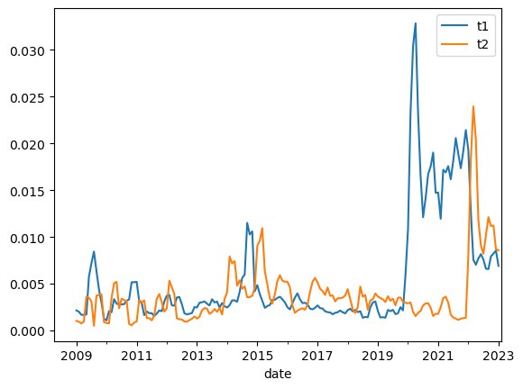

```python
df["t1"] = [t[31] for t in topics]
df["t2"] = [t[42] for t in topics]
df.resample("M", on="date")[['t1','t2']].mean().rolling(3, center=True).mean().plot()
```